# **数据挖掘第一章-导论**

## 柱状图

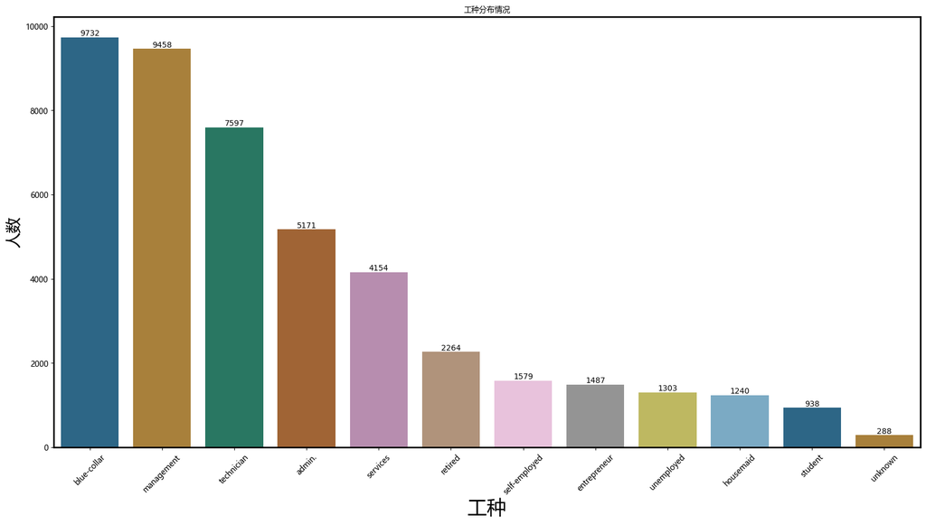

```python
barplot(figsize=(20,10),
        x=data.job.value_counts().index,
        y=data.job.value_counts(),
        title='工种分布情况',
        xlabel='工种',
        ylabel='人数')
```

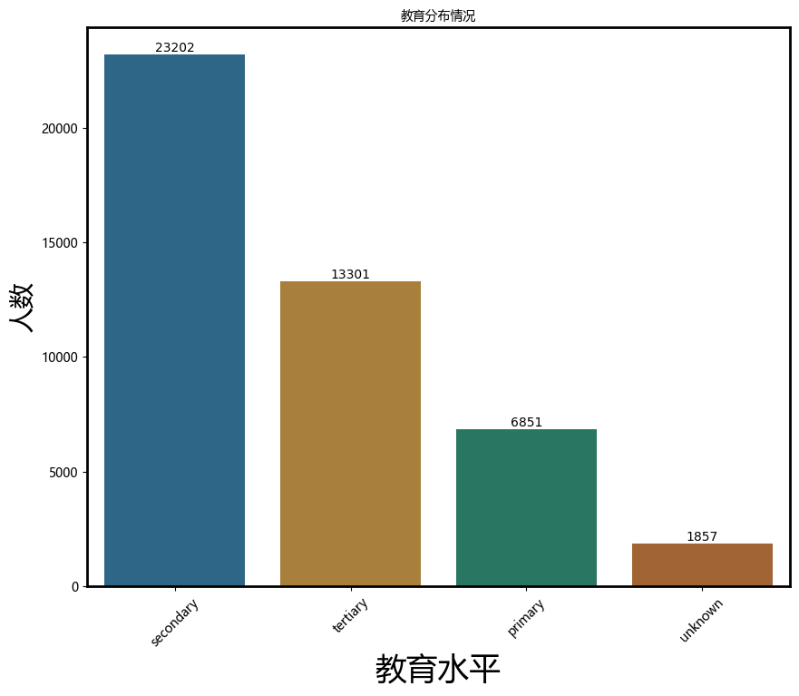

```python
barplot(figsize=(10,8),
        x=data.education.value_counts().index,
        y=data.education.value_counts(),
        title='教育分布情况',
        xlabel='教育水平',
        ylabel='人数')
```

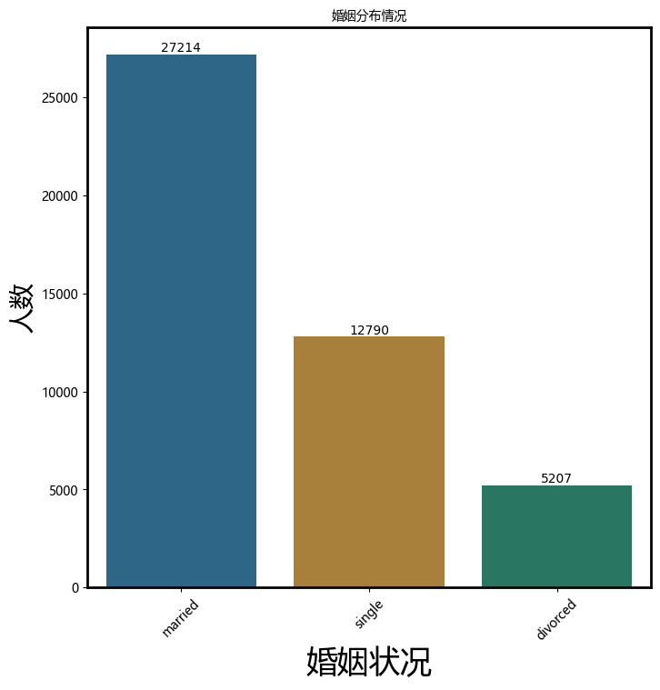

```python
barplot(figsize=(8,8),
        x=data.marital.value_counts().index,
        y=data.marital.value_counts(),
        title='婚姻分布情况',
        xlabel='婚姻状况',
        ylabel='人数')
```

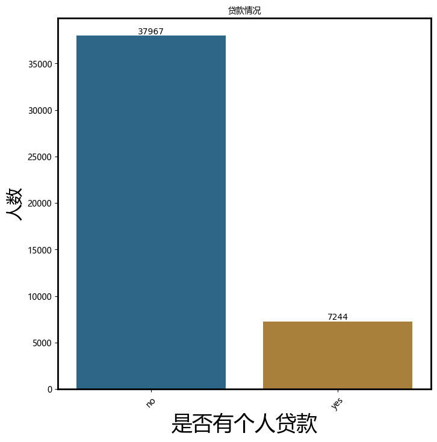

```python
barplot(figsize=(8,8),
        x=data.loan.value_counts().index,
        y=data.loan.value_counts(),
        title='贷款情况',
        xlabel='是否有个人贷款',
        ylabel='人数')
```

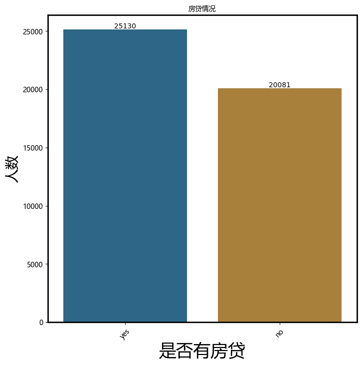

```python
barplot(figsize=(8,8),
        x=data.housing.value_counts().index,
        y=data.housing.value_counts(),
        title='房贷情况',
        xlabel='是否有房贷',
        ylabel='人数')
```

通过单变量的可视化，或者变量之间联立的可视化，可以快速帮助我们发现数据分布的规律。  
通过可视化可以为我们提供数据处理的思路。

# 数据预处理 & 特征工程

```
这边其实应该先切分一下数据集的，用训练集来训练模型，用测试集来模拟未知的数据。
我们在训练集上训练好模型，然后看模型对未知情况的预测能力如何。
因为机器学习强调的就是对未知数据的预测能力，因为是课程演示，所以就简化步骤，方便理解。
由于数据没有缺失值，所以就直接开始特征工程
```

## 连续型变量处理

```
部分算法对数据的分布会有要求，比如k-means/线性回归/逻辑回归/神经网络等等。
对变量进行处理就是尽量让算法满足算法的前提假设或者让数据更加合理。
```

```python
# 归一化
from sklearn.preprocessing import MinMaxScaler

scaler = MinMaxScaler()
data.age = scaler.fit_transform(np.reshape(data.age.tolist(), (-1, 1)))
data.balance = scaler.fit_transform(np.reshape(data.balance.tolist(), (-1, 1)))
data.duration = scaler.fit_transform(np.reshape(data.duration.tolist(), (-1, 1)))
data.day = scaler.fit_transform(np.reshape(data.day.tolist(), (-1, 1)))
data.pdays = scaler.fit_transform(np.reshape(data.pdays.tolist(), (-1, 1)))
data.duration = scaler.fit_transform(np.reshape(data.duration.tolist(), (-1, 1)))
data.previous = scaler.fit_transform(np.reshape(data.previous.tolist(), (-1, 1)))
```

```python
data
```

|  | age | job | marital | education | default | balance | housing | loan | contact | day | month | duration | campaign | pdays | previous | poutcome | y |
| --- | --- | --- | --- | --- | --- | --- | --- | --- | --- | --- | --- | --- | --- | --- | --- | --- | --- |
| 0 | 0.519481 | management | married | tertiary | no | 0.092259 | yes | no | unknown | 0.133333 | may | 0.053070 | 1 | 0.000000 | 0.000000 | unknown | no |
| 1 | 0.337662 | technician | single | secondary | no | 0.073067 | yes | no | unknown | 0.133333 | may | 0.030704 | 1 | 0.000000 | 0.000000 | unknown | no |
| 2 | 0.194805 | entrepreneur | married | secondary | no | 0.072822 | yes | yes | unknown | 0.133333 | may | 0.015453 | 1 | 0.000000 | 0.000000 | unknown | no |
| 3 | 0.376623 | blue-collar | married | unknown | no | 0.086476 | yes | no | unknown | 0.133333 | may | 0.018707 | 1 | 0.000000 | 0.000000 | unknown | no |
| 4 | 0.194805 | unknown | single | unknown | no | 0.072812 | no | no | unknown | 0.133333 | may | 0.040260 | 1 | 0.000000 | 0.000000 | unknown | no |
| ... | ... | ... | ... | ... | ... | ... | ... | ... | ... | ... | ... | ... | ... | ... | ... | ... | ... |
| 45206 | 0.428571 | technician | married | tertiary | no | 0.080293 | no | no | cellular | 0.533333 | nov | 0.198658 | 3 | 0.000000 | 0.000000 | unknown | yes |
| 45207 | 0.688312 | retired | divorced | primary | no | 0.088501 | no | no | cellular | 0.533333 | nov | 0.092721 | 2 | 0.000000 | 0.000000 | unknown | yes |
| 45208 | 0.701299 | retired | married | secondary | no | 0.124689 | no | no | cellular | 0.533333 | nov | 0.229158 | 5 | 0.212156 | 0.010909 | success | yes |
| 45209 | 0.506494 | blue-collar | married | secondary | no | 0.078868 | no | no | telephone | 0.533333 | nov | 0.103294 | 4 | 0.000000 | 0.000000 | unknown | no |
| 45210 | 0.246753 | entrepreneur | married | secondary | no | 0.099777 | no | no | cellular | 0.533333 | nov | 0.073404 | 2 | 0.216743 | 0.040000 | other | no |

45211 rows × 17 columns

## 分类型变量的处理

```
对于字母和文本的数据，我们的模型还无法直接识别，所以需要对分类型变量进行编码操作。
标签编码、哑变量编码、one-hot编码这三种编码方式会比较常见，当然统计量编码也是快速提分的杀器。
```

job的类型： ['blue-collar', 'management', 'technician', 'admin.', 'services', 'retired', 'self-employed', 'entrepreneur', 'unemployed', 'housemaid','student', 'unknown'] 对于job这种，你如果采用 1 2 3 4这种连续型的编码，合理么？ Job之间没有大小关系，只有区别，所以采用Label-encoding不合理 我们会采用one-hot来对这种变量编码 同样的还有 marital的类型：['married', 'single', 'divorced'] contact的类型：['cellular', 'unknown', 'telephone'] poutcome的类型：['unknown', 'failure', 'other', 'success']

教育这个变量是有大小关系的。 education的类型:['secondary', 'tertiary', 'primary', 'unknown'] month：['may', 'jul', 'aug', 'jun', 'nov', 'apr', 'feb', 'jan', 'oct', 'sep', 'mar', 'dec'] 正常情况下时间变量一般是这样的：2022-10-01 然后我们会处理成：2022 10 01 相当于拆开三个变量

二分类变量： default/housing/loan

```python
from sklearn.preprocessing import OneHotEncoder

onehot_encoder = OneHotEncoder(handle_unknown='ignore')
one_hot_column = ['job', 'marital', 'contact', 'poutcome']
for col in one_hot_column:
    columns = []
    for j in range(len(data.loc[:, col].value_counts())):
        columns.append(col + '_' + str(j))
    onehot_encoder.fit(np.reshape(data.loc[:, col].tolist(), (-1,1)))
    tmp = pd.DataFrame(onehot_encoder.transform(np.reshape(data.loc[:, col].tolist(), (-1,1))).toarray())
    tmp.columns = columns
    data = pd.concat([data, tmp], axis=1)
    data.drop(columns=col, inplace=True)
```

```python
data.columns
# 可以看到原本的17列在one-hot之后变成35列了
# 所以one-hot编码只能处理一些少类别的分类型变量，一旦分类型变量的类比较多，数据集就会爆炸
```

```
Index(['age', 'education', 'default', 'balance', 'housing', 'loan', 'day',
       'month', 'duration', 'campaign', 'pdays', 'previous', 'y', 'job_0',
       'job_1', 'job_2', 'job_3', 'job_4', 'job_5', 'job_6', 'job_7', 'job_8',
       'job_9', 'job_10', 'job_11', 'marital_0', 'marital_1', 'marital_2',
       'contact_0', 'contact_1', 'contact_2', 'poutcome_0', 'poutcome_1',
       'poutcome_2', 'poutcome_3'],
      dtype='object')
```

```python
data.education = data.education.apply(lambda x:{'unknown':-1, 'primary':1, 'secondary':2, 'tertiary':3}[x])
data.month = data.month.apply(lambda x:{'jan':1, 'feb':2, 'mar':3, 'apr':4, 'may':5, 'jun':6,
                                             'jul':7, 'aug':8, 'sep':9, 'oct':10, 'nov':11, 'dec':12}[x])
data.default = data.default.apply(lambda x:{'yes':1, 'no':0}[x])
data.housing = data.housing.apply(lambda x:{'yes':1, 'no':0}[x])
data.loan = data.loan.apply(lambda x:{'yes':1, 'no':0}[x])
data.y = data.y.apply(lambda x:{'yes':1, 'no':0}[x])
```

```python
# 这样子数据就被我们清理成
data
```

|  | age | education | default | balance | housing | loan | day | month | duration | campaign | ... | marital_0 | marital_1 | marital_2 | contact_0 | contact_1 | contact_2 | poutcome_0 | poutcome_1 | poutcome_2 | poutcome_3 |
| --- | --- | --- | --- | --- | --- | --- | --- | --- | --- | --- | --- | --- | --- | --- | --- | --- | --- | --- | --- | --- | --- |
| 0 | 0.519481 | 3 | 0 | 0.092259 | 1 | 0 | 0.133333 | 5 | 0.053070 | 1 | ... | 0.0 | 1.0 | 0.0 | 0.0 | 0.0 | 1.0 | 0.0 | 0.0 | 0.0 | 1.0 |
| 1 | 0.337662 | 2 | 0 | 0.073067 | 1 | 0 | 0.133333 | 5 | 0.030704 | 1 | ... | 0.0 | 0.0 | 1.0 | 0.0 | 0.0 | 1.0 | 0.0 | 0.0 | 0.0 | 1.0 |
| 2 | 0.194805 | 2 | 0 | 0.072822 | 1 | 1 | 0.133333 | 5 | 0.015453 | 1 | ... | 0.0 | 1.0 | 0.0 | 0.0 | 0.0 | 1.0 | 0.0 | 0.0 | 0.0 | 1.0 |
| 3 | 0.376623 | -1 | 0 | 0.086476 | 1 | 0 | 0.133333 | 5 | 0.018707 | 1 | ... | 0.0 | 1.0 | 0.0 | 0.0 | 0.0 | 1.0 | 0.0 | 0.0 | 0.0 | 1.0 |
| 4 | 0.194805 | -1 | 0 | 0.072812 | 0 | 0 | 0.133333 | 5 | 0.040260 | 1 | ... | 0.0 | 0.0 | 1.0 | 0.0 | 0.0 | 1.0 | 0.0 | 0.0 | 0.0 | 1.0 |
| ... | ... | ... | ... | ... | ... | ... | ... | ... | ... | ... | ... | ... | ... | ... | ... | ... | ... | ... | ... | ... | ... |
| 45206 | 0.428571 | 3 | 0 | 0.080293 | 0 | 0 | 0.533333 | 11 | 0.198658 | 3 | ... | 0.0 | 1.0 | 0.0 | 1.0 | 0.0 | 0.0 | 0.0 | 0.0 | 0.0 | 1.0 |
| 45207 | 0.688312 | 1 | 0 | 0.088501 | 0 | 0 | 0.533333 | 11 | 0.092721 | 2 | ... | 1.0 | 0.0 | 0.0 | 1.0 | 0.0 | 0.0 | 0.0 | 0.0 | 0.0 | 1.0 |
| 45208 | 0.701299 | 2 | 0 | 0.124689 | 0 | 0 | 0.533333 | 11 | 0.229158 | 5 | ... | 0.0 | 1.0 | 0.0 | 1.0 | 0.0 | 0.0 | 0.0 | 0.0 | 1.0 | 0.0 |
| 45209 | 0.506494 | 2 | 0 | 0.078868 | 0 | 0 | 0.533333 | 11 | 0.103294 | 4 | ... | 0.0 | 1.0 | 0.0 | 0.0 | 1.0 | 0.0 | 0.0 | 0.0 | 0.0 | 1.0 |
| 45210 | 0.246753 | 2 | 0 | 0.099777 | 0 | 0 | 0.533333 | 11 | 0.073404 | 2 | ... | 0.0 | 1.0 | 0.0 | 1.0 | 0.0 | 0.0 | 0.0 | 1.0 | 0.0 | 0.0 |

45211 rows × 35 columns